# Homework 4

STAT 430, Spring 2017

Due: Friday, February 24 by 11:59 PM

# Exercise 1

**[10 points]** We once again return to the data found in `auto-train.csv` and `auto-test.csv` which contain train and test data respectively. `auto.csv` is provided but not used. It is a modification of the `Auto` data from the `ISLR` package. Use `mpg` as the response. Train the following models:

- Additive Logistic Regression
- LDA
- QDA
- Naive Bayes

Report test and train accuracies for both. Indicate which model performs best.

You should consider coercing the response to be a factor variable.

**Solution:**

```r
# import data
auto_train = read_csv("auto-train.csv")
auto_test = read_csv("auto-test.csv")
```

```r
# coerce to factor
auto_train$mpg = as.factor(auto_train$mpg)
auto_test$mpg = as.factor(auto_test$mpg)
```

```r
# load packages
library(MASS)
library(e1071)
library(caret)
```

```r
# train models
auto_lr = glm(mpg ~ ., data = auto_train, family = "binomial")
auto_lda = lda(mpg ~ ., data = auto_train)
auto_qda = qda(mpg ~ ., data = auto_train)
auto_nb = naiveBayes(mpg ~ ., data = auto_train)
```

```r
# get predictions

auto_lr_train_pred = ifelse(predict(auto_lr, auto_train) > 0, 1, 0)
auto_lr_test_pred = ifelse(predict(auto_lr, auto_test) > 0, 1, 0)

auto_lda_train_pred = predict(auto_lda, auto_train)$class
auto_lda_test_pred = predict(auto_lda, auto_test)$class

auto_qda_train_pred = predict(auto_qda, auto_train)$class
auto_qda_test_pred = predict(auto_qda, auto_test)$class

auto_nb_train_pred = predict(auto_nb, auto_train)
auto_nb_test_pred = predict(auto_nb, auto_test)
```

```r
# accuracy function
accuracy = function(actual, predicted) {
  mean(actual == predicted)
}
```

```r
# store results in data frame
auto_classifiers = c("Logistic", "LDA", "QDA", "Naive Bayes")

auto_train_acc = c(
  accuracy(predicted = auto_lr_train_pred, actual = auto_train$mpg),
  accuracy(predicted = auto_lda_train_pred, actual = auto_train$mpg),
  accuracy(predicted = auto_qda_train_pred, actual = auto_train$mpg),
  accuracy(predicted = auto_nb_train_pred, actual = auto_train$mpg)
)

auto_test_acc = c(
  accuracy(predicted = auto_lr_test_pred, actual = auto_test$mpg),
  accuracy(predicted = auto_lda_test_pred, actual = auto_test$mpg),
  accuracy(predicted = auto_qda_test_pred, actual = auto_test$mpg),
  accuracy(predicted = auto_nb_test_pred, actual = auto_test$mpg)
)

auto_results = data.frame(
  auto_classifiers,
  auto_train_acc,
  auto_test_acc
)

colnames(auto_results) = c("Method", "Train Accuracy", "Test Accuracy")
```

```r
# display data frame as table
knitr::kable(auto_results)
```

| Method | Train Accuracy | Test Accuracy |
| --- | --- | --- |
| Logistic | 0.8966667 | 0.9239130 |
| LDA | 0.9133333 | 0.9239130 |
| QDA | 0.9000000 | 0.8913043 |
| Naive Bayes | 0.9033333 | 0.9021739 |

Interestingly, both logistic and LDA perform equally well, as they both obtain the best test accuracy!

# Exercise 2

```r
library(MASS)

# setup parameters
num_obs = 1000

# means
mu_1 = c(10, 8.5)
mu_2 = c(20, 10)
mu_3 = c(10, 15)
mu_4 = c(10, 20)

# sigmas
sigma_1 = matrix(c(10, -4, -4, 8), 2, 2)
sigma_2 = matrix(c(5, -3, -3, 5), 2, 2)
sigma_3 = matrix(c(8, 3, 3, 8), 2, 2)
sigma_4 = matrix(c(8, 6, 6, 8), 2, 2)

# control randomization
set.seed(42)

# make train data
hw04_train = data.frame(

  # create response
  as.factor(c(rep("A", num_obs / 2), rep("B", num_obs),
              rep("C", num_obs * 2), rep("D", num_obs))),

  # create predictors
  rbind(
    mvrnorm(n = num_obs / 2, mu = mu_1, Sigma = sigma_1),
    mvrnorm(n = num_obs, mu = mu_2, Sigma = sigma_2),
    mvrnorm(n = num_obs * 2, mu = mu_3, Sigma = sigma_3),
    mvrnorm(n = num_obs, mu = mu_4, Sigma = sigma_4)
  )

)
# label variables
colnames(hw04_train) = c("y", "x1", "x2")


# make test data
hw04_test = data.frame(

  # create response
  as.factor(c(rep("A", num_obs), rep("B", num_obs),
              rep("C", num_obs), rep("D", num_obs))),

  # create predictors
  rbind(
    mvrnorm(n = num_obs, mu = mu_1, Sigma = sigma_1),
    mvrnorm(n = num_obs, mu = mu_2, Sigma = sigma_2),
    mvrnorm(n = num_obs, mu = mu_3, Sigma = sigma_3),
    mvrnorm(n = num_obs, mu = mu_4, Sigma = sigma_4)
  )

)
# label variables
colnames(hw04_test) = c("y", "x1", "x2")

# write to files
readr::write_csv(hw04_train, "hw04-train.csv")
readr::write_csv(hw04_test, "hw04-test.csv")

# clear workspace
rm(list = ls())
```

**[20 points]** Use the data found in `hw04-train.csv` and `hw04-test.csv` which contain train and test data respectively. Use `y` as the response. Coerce `y` to be a factor after importing the data.

Create an ellipse plot then train the following models:

- Additive Logistic Regression
- LDA
- LDA with Flat Prior
- QDA
- QDA with Flat Prior
- Naive Bayes

Report test and train accuracies for both. Indicate which model performs best. Do the results match the intution from the plot? Which class(es) is your best classifier classifying the best?

**Solution:**

```r
# read data
hw04_train = readr::read_csv("hw04-train.csv")
hw04_test = readr::read_csv("hw04-test.csv")

# coerce characters to factors
hw04_train$y = as.factor(hw04_train$y)
hw04_test$y = as.factor(hw04_test$y)
```

```r
# load packages
library(MASS)
library(e1071)
library(caret)
library(nnet)
library(ellipse)
```

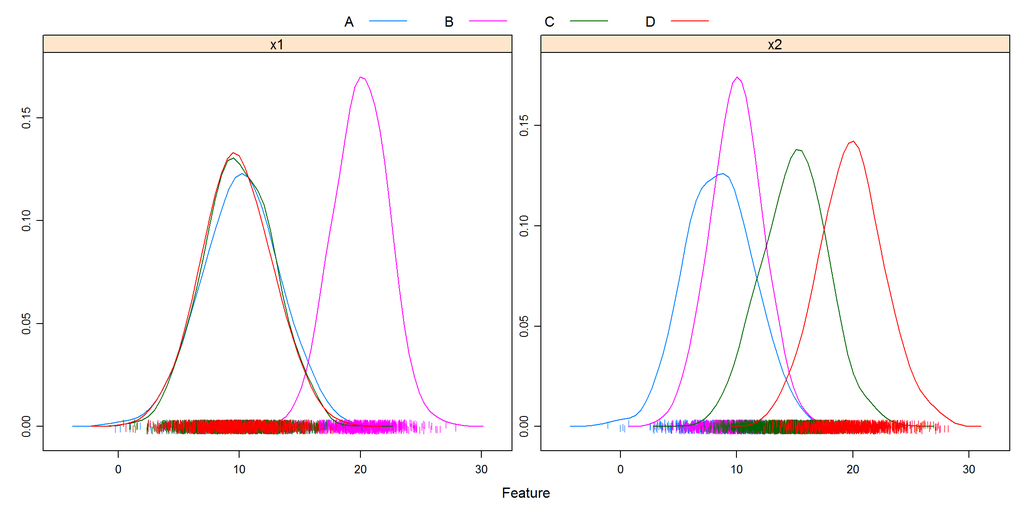

```r
caret::featurePlot(x = hw04_train[, 2:3],
            y = hw04_train$y,
            plot = "density",
            scales = list(x = list(relation="free"),
                          y = list(relation="free")),
            adjust = 1.5,
            pch = "|",
            layout = c(2, 1),
            auto.key = list(columns = 4))
```

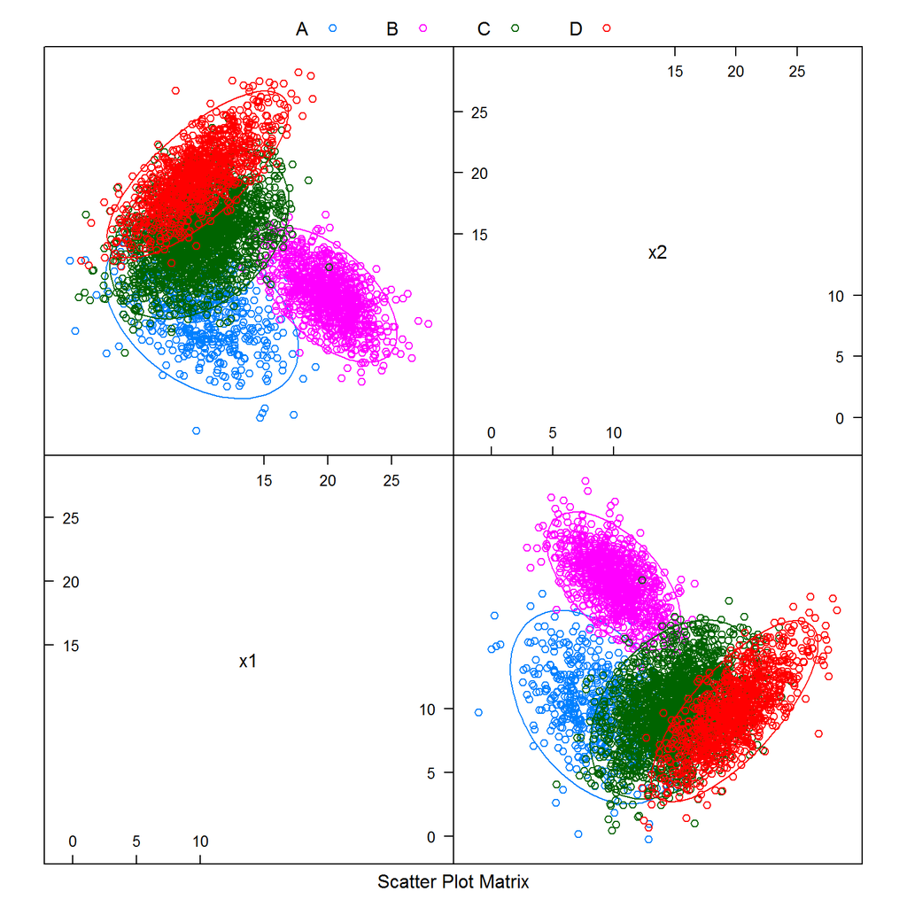

```r
featurePlot(x = hw04_train[, 2:3],
            y = hw04_train$y,
            plot = "ellipse",
            auto.key = list(columns = 4))
```

```r
# accuracy function
accuracy = function(actual, predicted) {
  mean(actual == predicted)
}
```

```r
# store results in data frame
hw04_classifiers = c("Logistic", "LDA", "LDA, Flat Prior", "QDA", "QDA, Flat Prior", "Naive Bayes")

hw04_train_acc = c(
  accuracy(hw04_train$y, predict(multinom(y ~ ., data = hw04_train, trace = FALSE), hw04_train)),
  accuracy(hw04_train$y, predict(lda(y ~ ., data = hw04_train), hw04_train)$class),
  accuracy(hw04_train$y, predict(lda(y ~ ., data = hw04_train, prior = c(1, 1, 1, 1) / 4), hw04_train)$class),
  accuracy(hw04_train$y, predict(qda(y ~ ., data = hw04_train), hw04_train)$class),
  accuracy(hw04_train$y, predict(qda(y ~ ., data = hw04_train, prior = c(1, 1, 1, 1) / 4), hw04_train)$class),
  accuracy(hw04_train$y, predict(naiveBayes(y ~ ., data = hw04_train), hw04_train))
)

hw04_test_acc = c(
  accuracy(hw04_test$y, predict(multinom(y ~ ., data = hw04_train, trace = FALSE), hw04_test)),
  accuracy(hw04_test$y, predict(lda(y ~ ., data = hw04_train), hw04_test)$class),
  accuracy(hw04_test$y, predict(lda(y ~ ., data = hw04_train, prior = c(1, 1, 1, 1) / 4), hw04_test)$class),
  accuracy(hw04_test$y, predict(qda(y ~ ., data = hw04_train), hw04_test)$class),
  accuracy(hw04_test$y, predict(qda(y ~ ., data = hw04_train, prior = c(1, 1, 1, 1) / 4), hw04_test)$class),
  accuracy(hw04_test$y, predict(naiveBayes(y ~ ., data = hw04_train), hw04_test))
)

hw04_results = data.frame(
  hw04_classifiers,
  hw04_train_acc,
  hw04_test_acc
)

colnames(hw04_results) = c("Method", "Train Accuracy", "Test Accuracy")
```

```r
# display data frame as table
knitr::kable(hw04_results)
```

| Method | Train Accuracy | Test Accuracy |
| --- | --- | --- |
| Logistic | 0.8517778 | 0.82575 |
| LDA | 0.8380000 | 0.80175 |
| LDA, Flat Prior | 0.8093333 | 0.83125 |
| QDA | 0.8522222 | 0.83075 |
| QDA, Flat Prior | 0.8208889 | 0.86000 |
| Naive Bayes | 0.8266667 | 0.80000 |

```r
# class proportions in train data
table(hw04_train$y) /  length(hw04_train$y)
```

```
##
##         A         B         C         D
## 0.1111111 0.2222222 0.4444444 0.2222222
```

```r
# class proportions in test data
table(hw04_test$y) /  length(hw04_test$y)
```

```
##
##    A    B    C    D
## 0.25 0.25 0.25 0.25
```

```r
# confusion matrix
table(predicted = predict(qda(y ~ ., data = hw04_train), hw04_test)$class,
      actual    = hw04_test$y)
```

```
##          actual
## predicted   A   B   C   D
##         A 703   3  33   0
##         B   8 976  11   0
##         C 279  21 849 205
##         D  10   0 107 795
```

Note: when using the older `read.csv()` strings are *automatically* imported as factors by deafult. This would seem useful here, but a terrible idea in general. It is better to import as a character, then later explicitly coerce to a factor if desired. For this reason, `read_csv()` does not even provide an option to import characters as a factor. (At least not one this instructor is aware of.)